# Actividad_03

# **2. Realice un análisis exploratorio bivariado de datos, enfocado en la relación entre la variable respuesta (precio) en función de la variable predictora (area construida) - incluir gráficos e indicadores apropiados interpretados.**

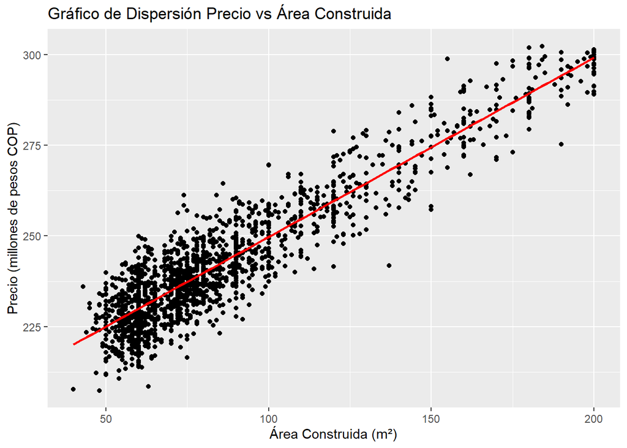

```r
# Gráfico de dispersión (precio vs área construida) con línea de tendencia central
ggplot(vivienda4, aes(x = areaconst, y = preciom)) +
  geom_point() +
  geom_smooth(method = "lm", color = "red", se = FALSE) +  # Línea de tendencia
  labs(x = "Área Construida (m²)", y = "Precio (millones de pesos COP)") +
  ggtitle("Gráfico de Dispersión Precio vs Área Construida")
```

El gráfico de dispersión sugiere una relación lineal entre las dos variables, mostrando que a medida que aumenta el área construida, también lo hace el precio de los apartamentos. Para confirmar esta relación positiva, se aplicaremos la prueba no paramétrica de Spearman, debido a la distribución no normal de los datos.

```r
cor.test(aptos$areaconst, aptos$preciom)
```

```
##
##  Pearson's product-moment correlation
##
## data:  aptos$areaconst and aptos$preciom
## t = 57.087, df = 1359, p-value < 2.2e-16
## alternative hypothesis: true correlation is not equal to 0
## 95 percent confidence interval:
##  0.8236972 0.8550345
## sample estimates:
##       cor
## 0.8400653
```

```r
cor.test(aptos$areaconst, aptos$preciom, method = "spearman")
```

```
##
##  Spearman's rank correlation rho
##
## data:  aptos$areaconst and aptos$preciom
## S = 109350726, p-value < 2.2e-16
## alternative hypothesis: true rho is not equal to 0
## sample estimates:
##       rho
## 0.7397452
```

# **3. Estime el modelo de regresión lineal simple entre precio=f(area)+ε. Interprete los coeficientes del modelo β0, β1 en caso de ser correcto.**

```r
# Estimar el modelo de regresión lineal simple
#modelo_regresion <- lm(preciom ~ areaconst, data = vivienda4)

# Mostrar un resumen del modelo
#summary(modelo_regresion)
```

#### **Para los apartamentos**

```r
modelo_regresion1 <- lm(aptos$preciom~aptos$areaconst)
resultado_prueba1 <- summary(modelo_regresion1)
resultado_prueba1
```

```
##
## Call:
## lm(formula = aptos$preciom ~ aptos$areaconst)
##
## Residuals:
##      Min       1Q   Median       3Q      Max
## -26.4137  -5.0770  -0.0061   4.6197  24.3348
##
## Coefficients:
##                  Estimate Std. Error t value Pr(>|t|)
## (Intercept)     2.002e+02  6.829e-01  293.11   <2e-16 ***
## aptos$areaconst 4.969e-01  8.704e-03   57.09   <2e-16 ***
## ---
## Signif. codes:  0 '***' 0.001 '**' 0.01 '*' 0.05 '.' 0.1 ' ' 1
##
## Residual standard error: 7.084 on 1359 degrees of freedom
## Multiple R-squared:  0.7057, Adjusted R-squared:  0.7055
## F-statistic:  3259 on 1 and 1359 DF,  p-value: < 2.2e-16
```

```r
# Mostrar un resumen del modelo
summary(resultado_prueba1)
```

```
##               Length Class  Mode
## call             2   -none- call
## terms            3   terms  call
## residuals     1361   -none- numeric
## coefficients     8   -none- numeric
## aliased          2   -none- logical
## sigma            1   -none- numeric
## df               3   -none- numeric
## r.squared        1   -none- numeric
## adj.r.squared    1   -none- numeric
## fstatistic       3   -none- numeric
## cov.unscaled     4   -none- numeric
```

El coeficiente del intercepto (β0) en el modelo de regresión lineal es de 200.2 millones de pesos COP. Sin embargo, su interpretación en este contexto puede carecer de significado práctico, porque este valor hace referencia al precio estimado cuando el área construida es igual a cero, lo cual no tiene una interpretación realista en el contexto de bienes raíces.

#### **Para las casas**

```r
modelo_regresionCasas = lm (preciom ~ areaconst, casas)
summary(modelo_regresionCasas)
```

```
##
## Call:
## lm(formula = preciom ~ areaconst, data = casas)
##
## Residuals:
##      Min       1Q   Median       3Q      Max
## -18.9715  -4.4788  -0.2916   4.4190  21.9460
##
## Coefficients:
##              Estimate Std. Error t value Pr(>|t|)
## (Intercept) 199.29486    1.44773  137.66   <2e-16 ***
## areaconst     0.49991    0.01047   47.76   <2e-16 ***
## ---
## Signif. codes:  0 '***' 0.001 '**' 0.01 '*' 0.05 '.' 0.1 ' ' 1
##
## Residual standard error: 7.341 on 324 degrees of freedom
## Multiple R-squared:  0.8756, Adjusted R-squared:  0.8753
## F-statistic:  2281 on 1 and 324 DF,  p-value: < 2.2e-16
```